# Normality is for residuals

Clay Ford

11/2/2020

The normality assumption in linear modeling (multiple regression) is **on the residuals**, not the dependent or independent variables.

Look at the following data. Size is n = 14:

```r
str(d)
```

```
## 'data.frame':    14 obs. of  4 variables:
##  $ y : num  14.54 15.65 9.41 4.96 13.93 ...
##  $ x1: num  0.266 0.372 0.573 0.908 0.202 ...
##  $ x2: num  0.54 0.957 0.147 1.391 0.762 ...
##  $ x3: Factor w/ 2 levels "1","2": 1 1 1 1 1 1 1 2 2 2 ...
```

Let’s say we want to model `y` as an additive function of `x1`, `x2` and `x3`. This is basic multiple regression. Before we begin, let’s examine the distributions of the numeric data. **None of them are remotely Normal.**

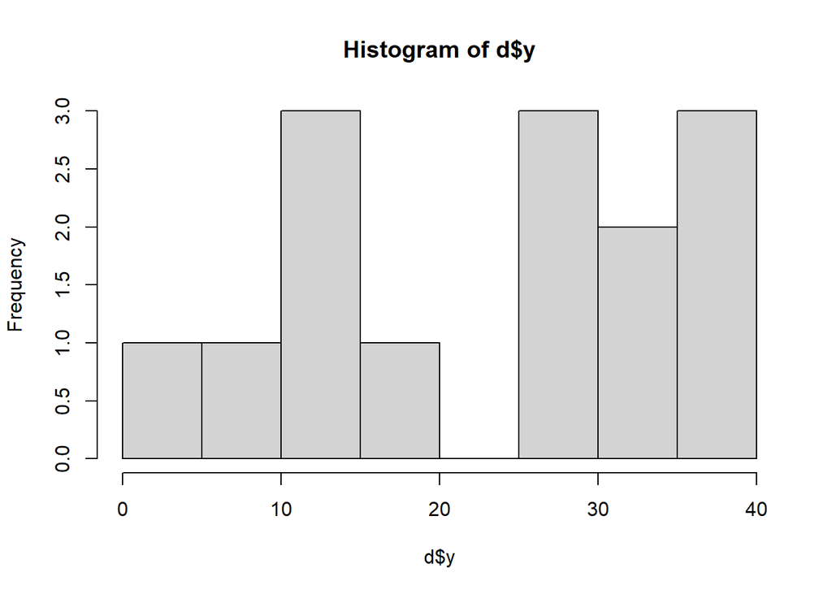

```r
hist(d$y)
```

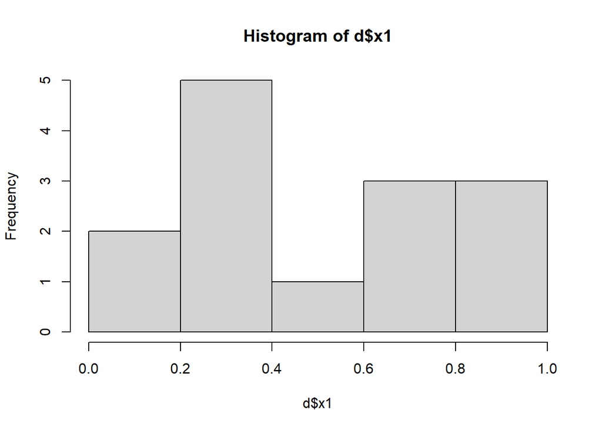

```r
hist(d$x1)
```

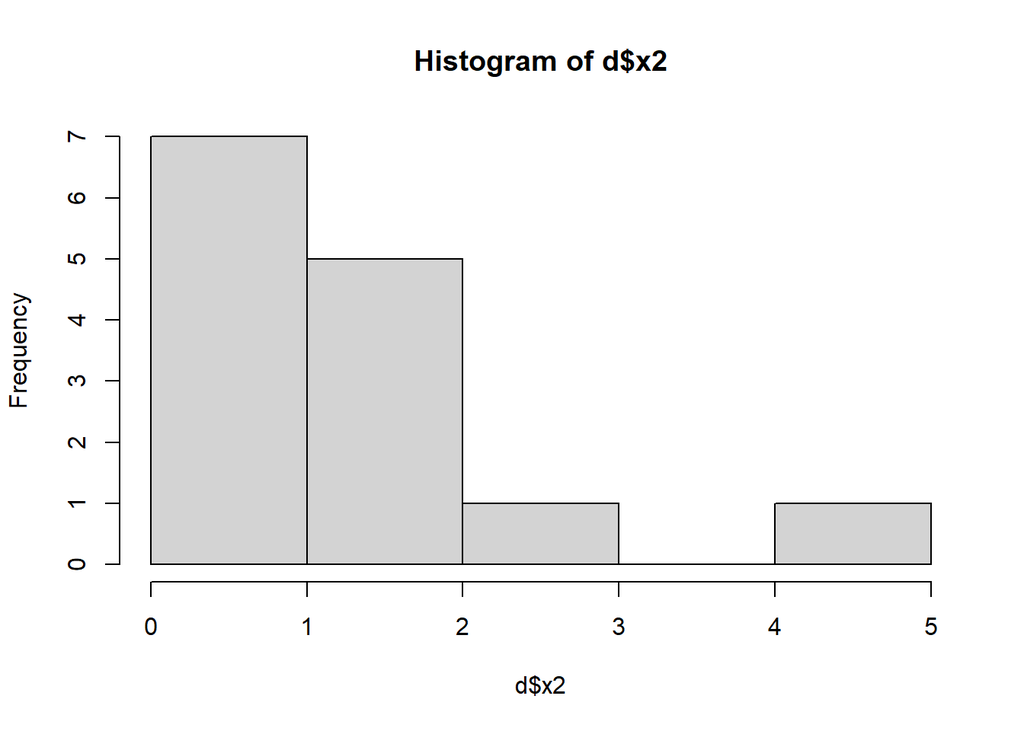

```r
hist(d$x2)
```

That doesn’t matter. We can still proceed with multiple regression:

```r
m <- lm(y ~ x1 + x2 + x3, data = d)
```

**NOW** is the time to assess the normality assumption. One way is via QQ-Plot, which is built-in to R as follows. The dots should lie close to the diagonal line. The normality assumption checks out. It really doesn’t get any better than this.

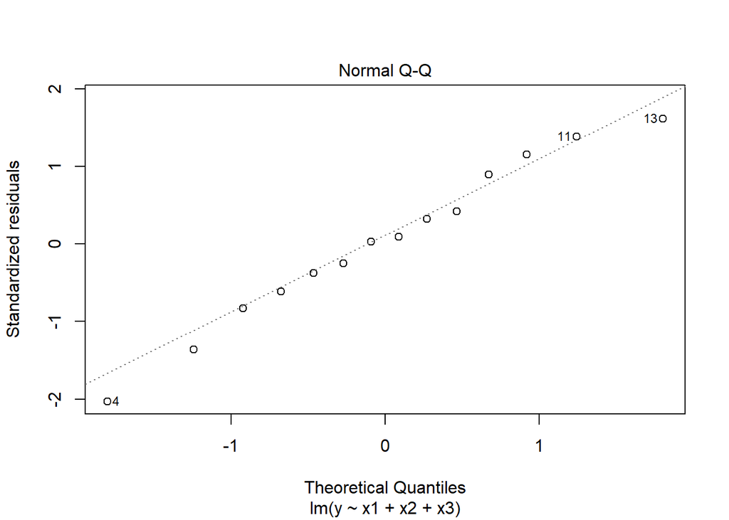

```r
plot(m, which = 2)
```

We could also look at a histogram of the residuals. This looks pretty good considering our small sample size.

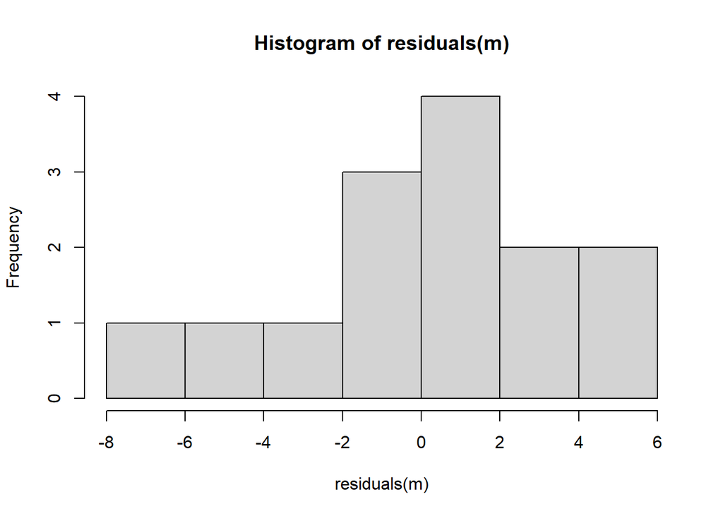

```r
hist(residuals(m))
```

We could even do a Shapiro-Wilk normality test, though I don’t care for it since it encourages binary Yes-No thinking. In this case however, the result agrees with the QQ plot and histogram. We fail to reject the Null of Normality.

```r
shapiro.test(residuals(m))
```

```
##
##  Shapiro-Wilk normality test
##
## data:  residuals(m)
## W = 0.98133, p-value = 0.9818
```

### How I generated the data

Here is the R code I used to generate the data. Notice the only values that were generated from a Normal distribution are the errors (or residuals): `rnorm(n, sd = 4.7)`. The `x1` and `x2` values were drawn from uniform and exponential distributions, respectively. The `x3` variable is a categorical variable with 2 levels, 7 each.

```r
set.seed(1)
n <- 14
# generate IVs
x1 <- runif(n)
x2 <- rexp(n)
x3 <- gl(n = 2, k = 7)
# generate DV
y <- 7.8 + 1.2 * x1 + 3.9 * x2 + 20.5 * (x3 == "2") + rnorm(n, sd = 4.7)
d <- data.frame(y, x1, x2, x3)
```

Notice the regression does a decent job of recovering the “True” values used to generate the data, except for `x1`.

```r
summary(m)
```

```
##
## Call:
## lm(formula = y ~ x1 + x2 + x3, data = d)
##
## Residuals:
##     Min      1Q  Median      3Q     Max
## -6.2686 -1.5815  0.1818  1.8399  4.8533
##
## Coefficients:
##             Estimate Std. Error t value Pr(>|t|)
## (Intercept)  13.7219     2.5349   5.413 0.000296 ***
## x1           -9.0774     3.7792  -2.402 0.037192 *
## x2            4.1378     0.9807   4.219 0.001773 **
## x32          18.4677     2.0250   9.120 3.67e-06 ***
## ---
## Signif. codes:  0 '***' 0.001 '**' 0.01 '*' 0.05 '.' 0.1 ' ' 1
##
## Residual standard error: 3.566 on 10 degrees of freedom
## Multiple R-squared:  0.9238, Adjusted R-squared:  0.901
## F-statistic: 40.43 on 3 and 10 DF,  p-value: 6.714e-06
```

True Intercept: 7.8  
Estimated Intercept: 13.721

True x1 coefficient: 1.2  
Estimated x1 coefficient: -9.077

True x2 coefficient: 3.9  
Estimated x3 coefficient: 4.137

True x3 coefficient: 20.5  
Estimated x3 coefficient: 18.467

*And all of this worked despite none of the predictors or dependent variable being normally distributed.*